# LMwithPred

Arlene Faye Salvador

11/5/2020

We are using a linear model to predict a simulated strength score based on arm strength and or grip strength.

```r
dataF <- read.csv(file="http://onlinestatbook.com/case_studies_rvls/physical_strength/data.txt",sep="",header=TRUE)
```

# model1

Scatterplot SIMS is a function of ARM

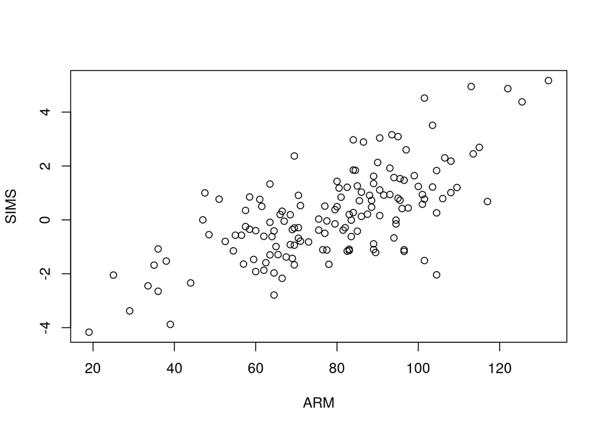

```r
plot(SIMS~ARM,data=dataF)
```

##Now with ggplot - first select the basic data

```r
basicNN <- ggplot(dataF,aes(y=SIMS,x=ARM))
```

##Now add in scatterplot

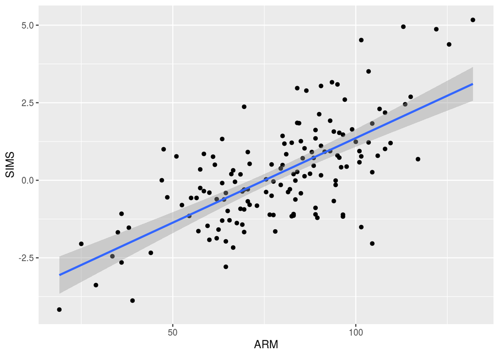

```r
basicNN + geom_point()+ geom_smooth(method=lm)
```

```r
model.1 <- lm(SIMS~ARM,data=dataF)
summary.lm(model.1)
```

```
##
## Call:
## lm(formula = SIMS ~ ARM, data = dataF)
##
## Residuals:
##     Min      1Q  Median      3Q     Max
## -3.6467 -0.7502 -0.0285  0.6875  3.0770
##
## Coefficients:
##              Estimate Std. Error t value Pr(>|t|)
## (Intercept) -4.095160   0.391745  -10.45   <2e-16 ***
## ARM          0.054563   0.004806   11.35   <2e-16 ***
## ---
## Signif. codes:  0 '***' 0.001 '**' 0.01 '*' 0.05 '.' 0.1 ' ' 1
##
## Residual standard error: 1.226 on 145 degrees of freedom
## Multiple R-squared:  0.4706, Adjusted R-squared:  0.467
## F-statistic: 128.9 on 1 and 145 DF,  p-value: < 2.2e-16
```

```r
new=data.frame(ARM=88,GRIP=94)
summary.lm(model.1,interval="prediction")
```

```
##
## Call:
## lm(formula = SIMS ~ ARM, data = dataF)
##
## Residuals:
##     Min      1Q  Median      3Q     Max
## -3.6467 -0.7502 -0.0285  0.6875  3.0770
##
## Coefficients:
##              Estimate Std. Error t value Pr(>|t|)
## (Intercept) -4.095160   0.391745  -10.45   <2e-16 ***
## ARM          0.054563   0.004806   11.35   <2e-16 ***
## ---
## Signif. codes:  0 '***' 0.001 '**' 0.01 '*' 0.05 '.' 0.1 ' ' 1
##
## Residual standard error: 1.226 on 145 degrees of freedom
## Multiple R-squared:  0.4706, Adjusted R-squared:  0.467
## F-statistic: 128.9 on 1 and 145 DF,  p-value: < 2.2e-16
```

This is a linear model of SIMS based on ARM strength. The adjusted R-square is equal to 0.467.

# model2

Scatterplot SIMS is a function of GRIP.

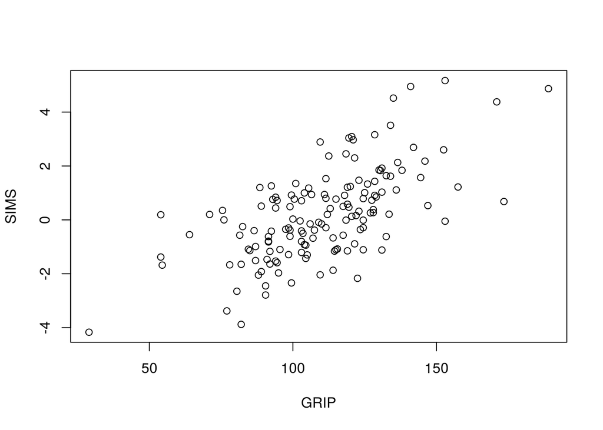

```r
plot(SIMS~GRIP,data=dataF)
```

##Now with ggplot - first select the basic data

```r
basicNN <- ggplot(dataF,aes(y=SIMS,x=GRIP))
```

##Now add in scatterplot

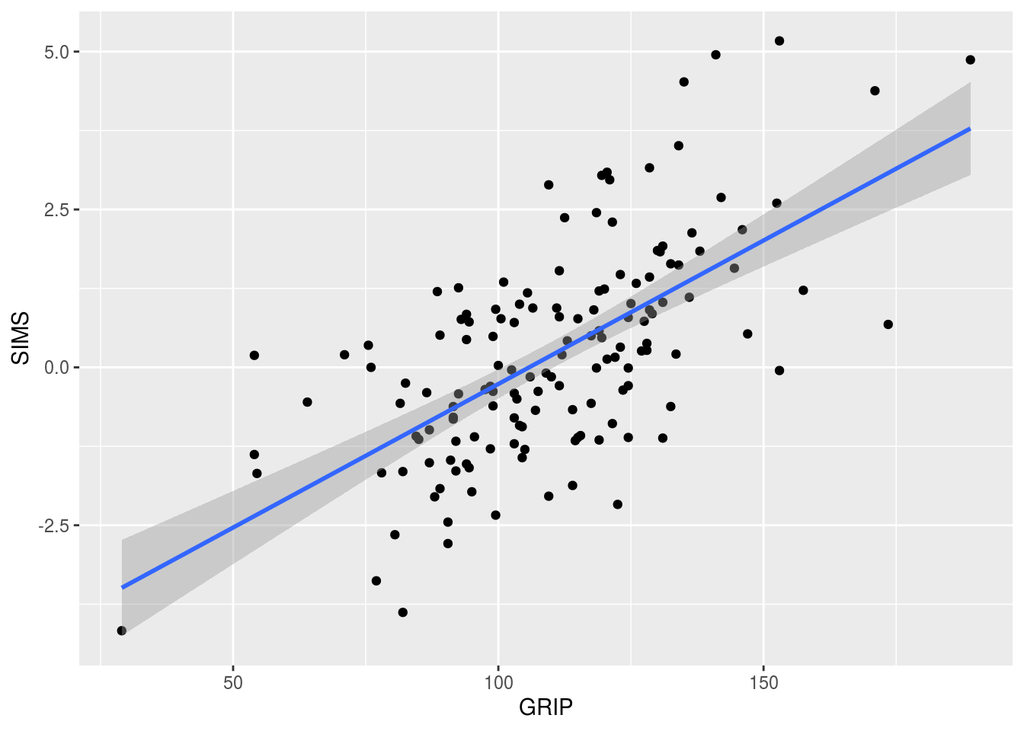

```r
basicNN + geom_point()+ geom_smooth(method=lm)
```

```r
model.2 <- lm(SIMS~GRIP,data=dataF)
summary.lm(model.2)
```

```
##
## Call:
## lm(formula = SIMS ~ GRIP, data = dataF)
##
## Residuals:
##     Min      1Q  Median      3Q     Max
## -2.9295 -0.8708 -0.1219  0.8039  3.3494
##
## Coefficients:
##              Estimate Std. Error t value Pr(>|t|)
## (Intercept) -4.809675   0.511141   -9.41   <2e-16 ***
## GRIP         0.045463   0.004535   10.03   <2e-16 ***
## ---
## Signif. codes:  0 '***' 0.001 '**' 0.01 '*' 0.05 '.' 0.1 ' ' 1
##
## Residual standard error: 1.295 on 145 degrees of freedom
## Multiple R-squared:  0.4094, Adjusted R-squared:  0.4053
## F-statistic: 100.5 on 1 and 145 DF,  p-value: < 2.2e-16
```

```r
predict(model.2,new,interval="prediction")
```

```
##          fit       lwr      upr
## 1 -0.5361543 -3.107961 2.035652
```

This is a linear model of SIMS based on GRIP strength. The adjusted R-square is equal to 0.4053. In this case model 1 is better than model 2 because the bigger R-squared.

# model3

Sims is a function of ARM and GRIP strength

```r
model.3 <- lm(SIMS~GRIP + ARM,data=dataF)
summary.lm(model.3)
```

```
##
## Call:
## lm(formula = SIMS ~ GRIP + ARM, data = dataF)
##
## Residuals:
##     Min      1Q  Median      3Q     Max
## -3.1846 -0.7380 -0.0641  0.7394  2.8634
##
## Coefficients:
##              Estimate Std. Error t value Pr(>|t|)
## (Intercept) -5.433871   0.461815 -11.766  < 2e-16 ***
## GRIP         0.024470   0.005158   4.744 4.99e-06 ***
## ARM          0.037311   0.005774   6.462 1.50e-09 ***
## ---
## Signif. codes:  0 '***' 0.001 '**' 0.01 '*' 0.05 '.' 0.1 ' ' 1
##
## Residual standard error: 1.144 on 144 degrees of freedom
## Multiple R-squared:  0.5422, Adjusted R-squared:  0.5358
## F-statistic: 85.26 on 2 and 144 DF,  p-value: < 2.2e-16
```

```r
predict(model.3,new,interval="prediction")
```

```
##         fit       lwr      upr
## 1 0.1496476 -2.132373 2.431668
```

The adjusted R-Square for model 3 is 0.5358, so it is a bigger model based on ARM.

```r
anova(model.1,model.3)
```

```
## Analysis of Variance Table
##
## Model 1: SIMS ~ ARM
## Model 2: SIMS ~ GRIP + ARM
##   Res.Df    RSS Df Sum of Sq      F    Pr(>F)
## 1    145 217.88
## 2    144 188.43  1     29.45 22.506 4.994e-06 ***
## ---
## Signif. codes:  0 '***' 0.001 '**' 0.01 '*' 0.05 '.' 0.1 ' ' 1
```

The p value is 0.00000499 this is less than 0.05 so we reject the null hypothesis and conclude that model 3 is better than model 1.